# Un modello statistico per prevedere il peso dei neonati

Dario De Caro

2024-10-01

# Carichiamo i pacchetti necessari

```r
library(readr)
library(knitr)
library(ggplot2)
library(ggpubr)
library(lmtest)
library(MASS)
library(car)
library(rgl)
library(moments)
```

# Importiamo il dataset

```r
data <- read_csv("neonati.csv")
attach(data)
```

# Verifichiamo le prime righe del dataset

```r
kable(head(data))
```

| Anni.madre | N.gravidanze | Fumatrici | Gestazione | Peso | Lunghezza | Cranio | Tipo.parto | Ospedale | Sesso |
| --- | --- | --- | --- | --- | --- | --- | --- | --- | --- |
| 26 | 0 | 0 | 42 | 3380 | 490 | 325 | Nat | osp3 | M |
| 21 | 2 | 0 | 39 | 3150 | 490 | 345 | Nat | osp1 | F |
| 34 | 3 | 0 | 38 | 3640 | 500 | 375 | Nat | osp2 | M |
| 28 | 1 | 0 | 41 | 3690 | 515 | 365 | Nat | osp2 | M |
| 20 | 0 | 0 | 38 | 3700 | 480 | 335 | Nat | osp3 | F |
| 32 | 0 | 0 | 40 | 3200 | 495 | 340 | Nat | osp2 | F |

# Verifichiamo la struttura del dataset

```r
str(data)
```

```
## spc_tbl_ [2,500 × 10] (S3: spec_tbl_df/tbl_df/tbl/data.frame)
##  $ Anni.madre  : num [1:2500] 26 21 34 28 20 32 26 25 22 23 ...
##  $ N.gravidanze: num [1:2500] 0 2 3 1 0 0 1 0 1 0 ...
##  $ Fumatrici   : num [1:2500] 0 0 0 0 0 0 0 0 0 0 ...
##  $ Gestazione  : num [1:2500] 42 39 38 41 38 40 39 40 40 41 ...
##  $ Peso        : num [1:2500] 3380 3150 3640 3690 3700 3200 3100 3580 3670 3700 ...
##  $ Lunghezza   : num [1:2500] 490 490 500 515 480 495 480 510 500 510 ...
##  $ Cranio      : num [1:2500] 325 345 375 365 335 340 345 349 335 362 ...
##  $ Tipo.parto  : chr [1:2500] "Nat" "Nat" "Nat" "Nat" ...
##  $ Ospedale    : chr [1:2500] "osp3" "osp1" "osp2" "osp2" ...
##  $ Sesso       : chr [1:2500] "M" "F" "M" "M" ...
##  - attr(*, "spec")=
##   .. cols(
##   ..   Anni.madre = col_double(),
##   ..   N.gravidanze = col_double(),
##   ..   Fumatrici = col_double(),
##   ..   Gestazione = col_double(),
##   ..   Peso = col_double(),
##   ..   Lunghezza = col_double(),
##   ..   Cranio = col_double(),
##   ..   Tipo.parto = col_character(),
##   ..   Ospedale = col_character(),
##   ..   Sesso = col_character()
##   .. )
##  - attr(*, "problems")=<externalptr>
```

Il dataset contiene 2500 osservazioni e 10 variabili. In particolare, sono presenti 3 variabili quantitative continue (Peso, Lunghezza e Cranio), 3 quantitative discrete (Anni madre, Gestazione e N. Gravidanze), e 4 variabili qualitative (Sesso, Ospedale, Tipo di Parto e Fumatrici). L’obiettivo dello studio è scoprire se è possibile prevedere il peso del neonato alla nascita date tutte le altre variabili. In particolare, si vuole studiare una relazione con le variabili della madre, per capire se queste hanno o meno un effetto significativo.

# Calcoliamo alcune statistiche descrittive

```r
df <- data[, sapply(data, is.numeric)]
df <- subset(df, select = -Fumatrici)
kable(summary(df))
```

|  | Anni.madre | N.gravidanze | Gestazione | Peso | Lunghezza | Cranio |
| --- | --- | --- | --- | --- | --- | --- |
|  | Min. : 0.00 | Min. : 0.0000 | Min. :25.00 | Min. : 830 | Min. :310.0 | Min. :235 |
|  | 1st Qu.:25.00 | 1st Qu.: 0.0000 | 1st Qu.:38.00 | 1st Qu.:2990 | 1st Qu.:480.0 | 1st Qu.:330 |
|  | Median :28.00 | Median : 1.0000 | Median :39.00 | Median :3300 | Median :500.0 | Median :340 |
|  | Mean :28.16 | Mean : 0.9812 | Mean :38.98 | Mean :3284 | Mean :494.7 | Mean :340 |
|  | 3rd Qu.:32.00 | 3rd Qu.: 1.0000 | 3rd Qu.:40.00 | 3rd Qu.:3620 | 3rd Qu.:510.0 | 3rd Qu.:350 |
|  | Max. :46.00 | Max. :12.0000 | Max. :43.00 | Max. :4930 | Max. :565.0 | Max. :390 |

Skewness

```r
kable(sapply(df, skewness))
```

|  | x |
| --- | --- |
| Anni.madre | 0.0428115 |
| N.gravidanze | 2.5142541 |
| Gestazione | -2.0653133 |
| Peso | -0.6470308 |
| Lunghezza | -1.5146991 |
| Cranio | -0.7850527 |

Kurtosis

```r
kable(sapply(df, kurtosis))
```

|  | x |
| --- | --- |
| Anni.madre | 3.380416 |
| N.gravidanze | 13.989406 |
| Gestazione | 11.258150 |
| Peso | 5.031532 |
| Lunghezza | 9.487174 |
| Cranio | 5.946206 |

Tutte le variabili presentano una distribuzione leptocurtica.

```r
df <- data[, sapply(data, is.factor) | sapply(data, is.character)]
df$Fumatrici = Fumatrici
kable(lapply(df, table))
```

| Var1 | Freq |
| --- | --- |
| Ces | 728 |
| Nat | 1772 |

| Var1 | Freq |
| --- | --- |
| osp1 | 816 |
| osp2 | 849 |
| osp3 | 835 |

| Var1 | Freq |
| --- | --- |
| F | 1256 |
| M | 1244 |

| Var1 | Freq |
| --- | --- |
| 0 | 2396 |
| 1 | 104 |

Le variabili Ospedale e Sesso mostrano una distribuzione bilanciata, mentre Tipo di parto e Fumatrici appaiono sbilanciate rispettivamente verso i parti Naturali e le madri non fumatrici.

# Visualizziamo graficamente

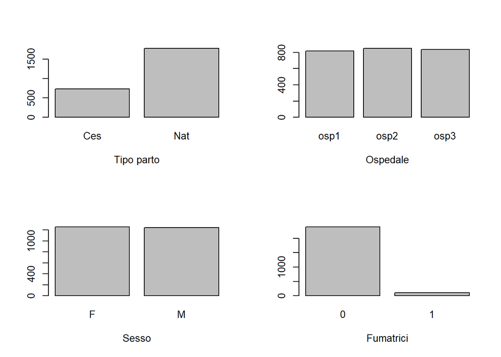

```r
par(mfrow=c(2, 2))

barplot(table(Tipo.parto), xlab = 'Tipo parto')
barplot(table(Ospedale), xlab = 'Ospedale')
barplot(table(Sesso), xlab = 'Sesso')
barplot(table(Fumatrici), xlab = 'Fumatrici')
```

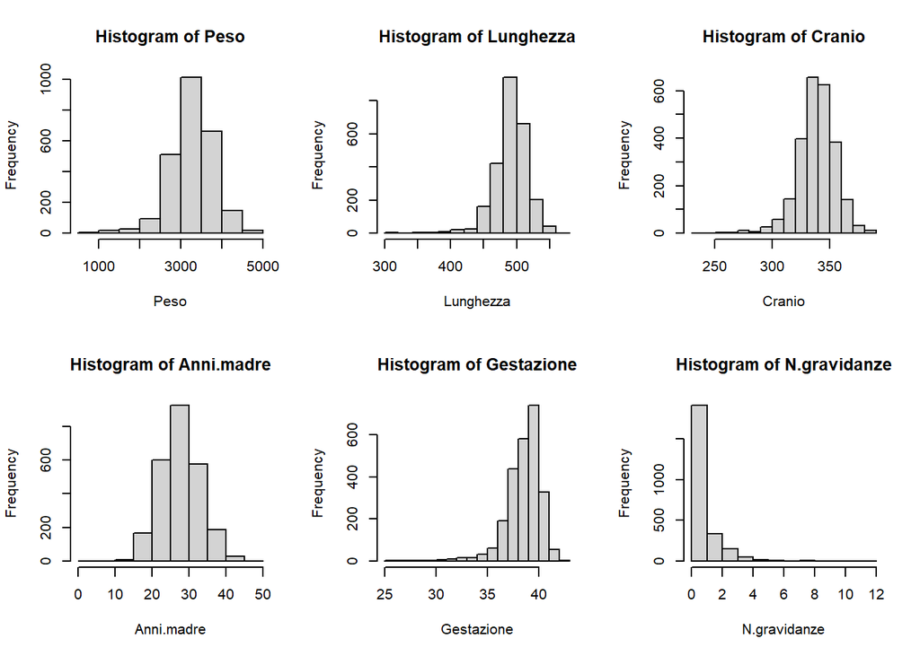

```r
par(mfrow=c(2, 3))

hist(Peso)
hist(Lunghezza)
hist(Cranio)
hist(Anni.madre)
hist(Gestazione)
hist(N.gravidanze)
```

L’analisi grafica conferma i risultati ottenuti precedentemente.

# Test t per la media del peso

```r
shapiro.test(data$Peso)
```

```
##
##  Shapiro-Wilk normality test
##
## data:  data$Peso
## W = 0.97066, p-value < 2.2e-16
```

```r
t.test(data$Peso, mu=3300)
```

```
##
##  One Sample t-test
##
## data:  data$Peso
## t = -1.516, df = 2499, p-value = 0.1296
## alternative hypothesis: true mean is not equal to 3300
## 95 percent confidence interval:
##  3263.490 3304.672
## sample estimates:
## mean of x
##  3284.081
```

La media del peso di questo campione di neonati è significativamente uguale a quelle della popolazione. Tuttavia, il campione non mostra una distribuzione normale.

# Test t per la media della lunghezza

```r
shapiro.test(data$Lunghezza)
```

```
##
##  Shapiro-Wilk normality test
##
## data:  data$Lunghezza
## W = 0.90941, p-value < 2.2e-16
```

```r
t.test(data$Lunghezza, mu=500)
```

```
##
##  One Sample t-test
##
## data:  data$Lunghezza
## t = -10.084, df = 2499, p-value < 2.2e-16
## alternative hypothesis: true mean is not equal to 500
## 95 percent confidence interval:
##  493.6598 495.7242
## sample estimates:
## mean of x
##   494.692
```

I valori medi della popolazione sono stati ricavati da:

https://www.ospedalebambinogesu.it/da-0-a-30-giorni-come-si-presenta-e-come-cresce-80012/#:~:text=In%20media%20il%20peso%20nascita,pari%20mediamente%20a%2050%20centimetri.

# Test per verificare differenze significative nel peso tra maschi e femmine

### Test per verificare le ipotesi

```r
shapiro.test(data$Peso[data$Sesso == 'M'])
```

```
##
##  Shapiro-Wilk normality test
##
## data:  data$Peso[data$Sesso == "M"]
## W = 0.96647, p-value = 2.321e-16
```

```r
shapiro.test(data$Peso[data$Sesso == 'F'])
```

```
##
##  Shapiro-Wilk normality test
##
## data:  data$Peso[data$Sesso == "F"]
## W = 0.96285, p-value < 2.2e-16
```

```r
bptest(data$Peso  ~ data$Sesso)
```

```
##
##  studentized Breusch-Pagan test
##
## data:  data$Peso ~ data$Sesso
## BP = 2.3503, df = 1, p-value = 0.1253
```

Le distribuzioni mostrano varianza omogenea, ma non distribuzione normale, pertanto è consigliabile esegire anche test non parametrici.

```r
t.test(Peso ~ Sesso, data = data)
```

```
##
##  Welch Two Sample t-test
##
## data:  Peso by Sesso
## t = -12.106, df = 2490.7, p-value < 2.2e-16
## alternative hypothesis: true difference in means between group F and group M is not equal to 0
## 95 percent confidence interval:
##  -287.1051 -207.0615
## sample estimates:
## mean in group F mean in group M
##        3161.132        3408.215
```

```r
wilcox.test(Peso ~ Sesso, data = data)
```

```
##
##  Wilcoxon rank sum test with continuity correction
##
## data:  Peso by Sesso
## W = 538641, p-value < 2.2e-16
## alternative hypothesis: true location shift is not equal to 0
```

Entrambi i test confermano una differenza significativa nel peso tra i due sessi.

# Test per verificare differenze significative nella lunghezza tra maschi e femmine

### Test per verificare le ipotesi

```r
shapiro.test(data$Lunghezza[data$Sesso == 'M'])
```

```
##
##  Shapiro-Wilk normality test
##
## data:  data$Lunghezza[data$Sesso == "M"]
## W = 0.92028, p-value < 2.2e-16
```

```r
shapiro.test(data$Lunghezza[data$Sesso == 'F'])
```

```
##
##  Shapiro-Wilk normality test
##
## data:  data$Lunghezza[data$Sesso == "F"]
## W = 0.89953, p-value < 2.2e-16
```

```r
bptest(data$Lunghezza  ~ data$Sesso)
```

```
##
##  studentized Breusch-Pagan test
##
## data:  data$Lunghezza ~ data$Sesso
## BP = 5.2544, df = 1, p-value = 0.02189
```

Le distribuzioni mostrano varianza non omogenea e distribuzione non normale, pertanto è consigliabile esegire anche test non parametrici.

```r
t.test(Lunghezza ~ Sesso, data = data)
```

```
##
##  Welch Two Sample t-test
##
## data:  Lunghezza by Sesso
## t = -9.582, df = 2459.3, p-value < 2.2e-16
## alternative hypothesis: true difference in means between group F and group M is not equal to 0
## 95 percent confidence interval:
##  -11.929470  -7.876273
## sample estimates:
## mean in group F mean in group M
##        489.7643        499.6672
```

```r
wilcox.test(Lunghezza ~ Sesso, data = data)
```

```
##
##  Wilcoxon rank sum test with continuity correction
##
## data:  Lunghezza by Sesso
## W = 594455, p-value < 2.2e-16
## alternative hypothesis: true location shift is not equal to 0
```

Entrambi i test confermano una differenza significativa nella lunghezza tra i due sessi.

# Test per verificare differenze significative nel diametro del cranio tra maschi e femmine

# Test per verificare le ipotesi

```r
shapiro.test(data$Cranio[data$Sesso == 'M'])
```

```
##
##  Shapiro-Wilk normality test
##
## data:  data$Cranio[data$Sesso == "M"]
## W = 0.97046, p-value = 3.006e-15
```

```r
shapiro.test(data$Cranio[data$Sesso == 'F'])
```

```
##
##  Shapiro-Wilk normality test
##
## data:  data$Cranio[data$Sesso == "F"]
## W = 0.95543, p-value < 2.2e-16
```

```r
bptest(data$Cranio  ~ data$Sesso)
```

```
##
##  studentized Breusch-Pagan test
##
## data:  data$Cranio ~ data$Sesso
## BP = 1.8761, df = 1, p-value = 0.1708
```

Le distribuzioni mostrano varianza omogenea e distribuzione non normale, pertanto è consigliabile esegire anche test non parametrici.

```r
t.test(Cranio ~ Sesso, data = data)
```

```
##
##  Welch Two Sample t-test
##
## data:  Cranio by Sesso
## t = -7.4102, df = 2491.4, p-value = 1.718e-13
## alternative hypothesis: true difference in means between group F and group M is not equal to 0
## 95 percent confidence interval:
##  -6.089912 -3.541270
## sample estimates:
## mean in group F mean in group M
##        337.6330        342.4486
```

```r
wilcox.test(Cranio ~ Sesso, data = data)
```

```
##
##  Wilcoxon rank sum test with continuity correction
##
## data:  Cranio by Sesso
## W = 641638, p-value = 9.633e-15
## alternative hypothesis: true location shift is not equal to 0
```

# Tabella di contingenza tra tipo di parto e ospedale

```r
tabella_parti <- table(data$Tipo.parto, data$Ospedale)
kable(tabella_parti)
```

|  | osp1 | osp2 | osp3 |
| --- | --- | --- | --- |
| Ces | 242 | 254 | 232 |
| Nat | 574 | 595 | 603 |

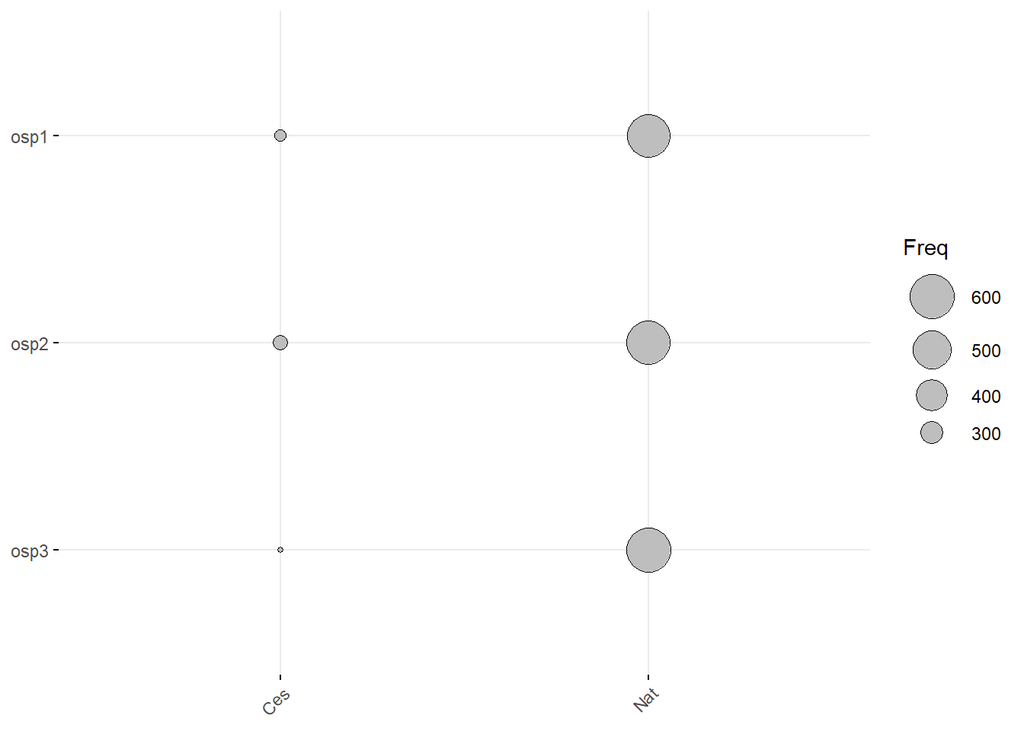

```r
ggballoonplot(as.data.frame(tabella_parti))
```

Sia la tabella, che il grafico non mostrano nessuna tendenza di maggiori parti cesarei tra ospedali.

# Test chi-quadrato per verificare differenze significative

```r
chisq.test(tabella_parti)
```

```
##
##  Pearson's Chi-squared test
##
## data:  tabella_parti
## X-squared = 1.0972, df = 2, p-value = 0.5778
```

Il test conferma l’ipotesi iniziale.

# Correlazione con variabili qualitative

```r
par(mfrow=c(2, 2))

boxplot(data$Peso ~ data$Sesso, main="Peso dei Neonati per Sesso", xlab='Sesso', ylab="Peso (grammi)")

boxplot(data$Peso ~ data$Ospedale, main="Peso dei Neonati per Ospedale",xlab = 'Ospedale', ylab="Peso (grammi)")
pairwise.t.test(data$Peso, data$Ospedale)
```

```
##
##  Pairwise comparisons using t tests with pooled SD
##
## data:  data$Peso and data$Ospedale
##
##      osp1 osp2
## osp2 0.99 -
## osp3 0.33 0.33
##
## P value adjustment method: holm
```

```r
boxplot(data$Peso ~ data$Fumatrici, main="Peso dei Neonati per Fumatrici", xlab='Madre fumatrice', ylab="Peso (grammi)")
t.test(Peso ~ Fumatrici, data = data)
```

```
##
##  Welch Two Sample t-test
##
## data:  Peso by Fumatrici
## t = 1.034, df = 114.1, p-value = 0.3033
## alternative hypothesis: true difference in means between group 0 and group 1 is not equal to 0
## 95 percent confidence interval:
##  -45.61354 145.22674
## sample estimates:
## mean in group 0 mean in group 1
##        3286.153        3236.346
```

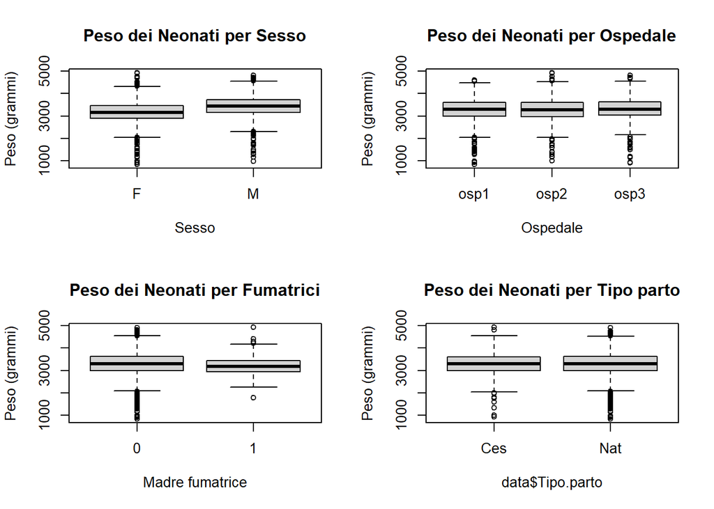

```r
boxplot(data$Peso ~ data$Tipo.parto, main="Peso dei Neonati per Tipo parto", ylab="Peso (grammi)")
```

```r
t.test(Peso ~ Tipo.parto, data = data)
```

```
##
##  Welch Two Sample t-test
##
## data:  Peso by Tipo.parto
## t = -0.12968, df = 1493, p-value = 0.8968
## alternative hypothesis: true difference in means between group Ces and group Nat is not equal to 0
## 95 percent confidence interval:
##  -46.27992  40.54037
## sample estimates:
## mean in group Ces mean in group Nat
##          3282.047          3284.916
```

Il sesso sembra essere la variabile qualitativa che più influisce sul peso.

# Matrice di correlazione per le variabili numeriche

```r
round(cor(data[c("Anni.madre", "Gestazione", "N.gravidanze",
           "Peso", "Lunghezza", "Cranio")]), digits = 2)
```

```
##              Anni.madre Gestazione N.gravidanze  Peso Lunghezza Cranio
## Anni.madre         1.00      -0.14         0.38 -0.02     -0.06   0.02
## Gestazione        -0.14       1.00        -0.10  0.59      0.62   0.46
## N.gravidanze       0.38      -0.10         1.00  0.00     -0.06   0.04
## Peso              -0.02       0.59         0.00  1.00      0.80   0.70
## Lunghezza         -0.06       0.62        -0.06  0.80      1.00   0.60
## Cranio             0.02       0.46         0.04  0.70      0.60   1.00
```

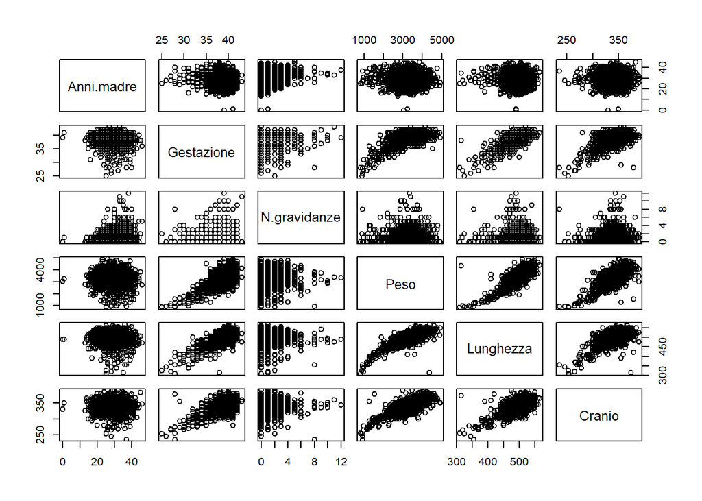

```r
pairs(data[c("Anni.madre", "Gestazione", "N.gravidanze",
           "Peso", "Lunghezza", "Cranio")])
```

Il peso appare linearmente correlato positivamente con la Lunghezza, il diametro del cranio e le settimane di gestazione.

# Modello di regressione lineare multipla

```r
data$Fumatrici <- ifelse(data$Fumatrici == 1, "Y", "N")
modello_intero = lm(Peso ~ Gestazione + Lunghezza + Ospedale + Cranio + Sesso + N.gravidanze + Tipo.parto + Fumatrici + Anni.madre, data=data)

summary(modello_intero)
```

```
##
## Call:
## lm(formula = Peso ~ Gestazione + Lunghezza + Ospedale + Cranio +
##     Sesso + N.gravidanze + Tipo.parto + Fumatrici + Anni.madre,
##     data = data)
##
## Residuals:
##      Min       1Q   Median       3Q      Max
## -1124.40  -181.66   -14.42   160.91  2611.89
##
## Coefficients:
##                 Estimate Std. Error t value Pr(>|t|)
## (Intercept)   -6738.4762   141.3087 -47.686  < 2e-16 ***
## Gestazione       32.5696     3.8187   8.529  < 2e-16 ***
## Lunghezza        10.2945     0.3007  34.236  < 2e-16 ***
## Ospedaleosp2    -11.2095    13.4379  -0.834   0.4043
## Ospedaleosp3     28.0958    13.4957   2.082   0.0375 *
## Cranio           10.4707     0.4260  24.578  < 2e-16 ***
## SessoM           77.5409    11.1776   6.937 5.08e-12 ***
## N.gravidanze     11.2665     4.6608   2.417   0.0157 *
## Tipo.partoNat    29.5254    12.0844   2.443   0.0146 *
## FumatriciY      -30.1631    27.5386  -1.095   0.2735
## Anni.madre        0.8921     1.1323   0.788   0.4308
## ---
## Signif. codes:  0 '***' 0.001 '**' 0.01 '*' 0.05 '.' 0.1 ' ' 1
##
## Residual standard error: 273.9 on 2489 degrees of freedom
## Multiple R-squared:  0.7289, Adjusted R-squared:  0.7278
## F-statistic: 669.2 on 10 and 2489 DF,  p-value: < 2.2e-16
```

# Selezione del modello tramite stepwise

Tramite procedura stepwise, vengono selezionate solo le variabili che minimizzano il BIC del modello, eliminando quelle non significative.

```r
modello_step <- stepAIC(modello_intero, direction = "both", k=log(nrow(data)))
```

```
## Start:  AIC=28139.32
## Peso ~ Gestazione + Lunghezza + Ospedale + Cranio + Sesso + N.gravidanze +
##     Tipo.parto + Fumatrici + Anni.madre
##
##                Df Sum of Sq       RSS   AIC
## - Anni.madre    1     46578 186809099 28132
## - Fumatrici     1     90019 186852540 28133
## - Ospedale      2    685979 187448501 28133
## - N.gravidanze  1    438452 187200974 28137
## - Tipo.parto    1    447929 187210450 28138
## <none>                      186762521 28139
## - Sesso         1   3611021 190373542 28179
## - Gestazione    1   5458403 192220925 28204
## - Cranio        1  45326172 232088693 28675
## - Lunghezza     1  87951062 274713583 29096
##
## Step:  AIC=28132.12
## Peso ~ Gestazione + Lunghezza + Ospedale + Cranio + Sesso + N.gravidanze +
##     Tipo.parto + Fumatrici
##
##                Df Sum of Sq       RSS   AIC
## - Fumatrici     1     90897 186899996 28126
## - Ospedale      2    692738 187501837 28126
## - Tipo.parto    1    448222 187257321 28130
## <none>                      186809099 28132
## - N.gravidanze  1    633756 187442855 28133
## + Anni.madre    1     46578 186762521 28139
## - Sesso         1   3618736 190427835 28172
## - Gestazione    1   5412879 192221978 28196
## - Cranio        1  45588236 232397335 28670
## - Lunghezza     1  87950050 274759149 29089
##
## Step:  AIC=28125.51
## Peso ~ Gestazione + Lunghezza + Ospedale + Cranio + Sesso + N.gravidanze +
##     Tipo.parto
##
##                Df Sum of Sq       RSS   AIC
## - Ospedale      2    701680 187601677 28119
## - Tipo.parto    1    440684 187340680 28124
## <none>                      186899996 28126
```

[output cut: 23 more lines]

```
##
## Step:  AIC=28117.58
## Peso ~ Gestazione + Lunghezza + Cranio + Sesso + N.gravidanze
##
##                Df Sum of Sq       RSS   AIC
## <none>                      188065546 28118
## - N.gravidanze  1    623141 188688687 28118
## + Tipo.parto    1    463870 187601677 28119
## + Ospedale      2    724866 187340680 28124
## + Fumatrici     1     91892 187973654 28124
## + Anni.madre    1     54816 188010731 28125
## - Sesso         1   3655292 191720838 28158
## - Gestazione    1   5464853 193530399 28181
## - Cranio        1  46108583 234174130 28658
## - Lunghezza     1  87632762 275698308 29066
```

```r
BIC(modello_step)
```

```
## [1] 35220.1
```

```r
summary(modello_step)
```

```
##
## Call:
## lm(formula = Peso ~ Gestazione + Lunghezza + Cranio + Sesso +
##     N.gravidanze, data = data)
##
## Residuals:
##      Min       1Q   Median       3Q      Max
## -1149.44  -180.81   -15.58   163.64  2639.72
##
## Coefficients:
##                Estimate Std. Error t value Pr(>|t|)
## (Intercept)  -6681.1445   135.7229 -49.226  < 2e-16 ***
## Gestazione      32.3321     3.7980   8.513  < 2e-16 ***
## Lunghezza       10.2486     0.3006  34.090  < 2e-16 ***
## Cranio          10.5402     0.4262  24.728  < 2e-16 ***
## SessoM          77.9927    11.2021   6.962 4.26e-12 ***
## N.gravidanze    12.4750     4.3396   2.875  0.00408 **
## ---
## Signif. codes:  0 '***' 0.001 '**' 0.01 '*' 0.05 '.' 0.1 ' ' 1
##
## Residual standard error: 274.6 on 2494 degrees of freedom
## Multiple R-squared:  0.727,  Adjusted R-squared:  0.7265
## F-statistic:  1328 on 5 and 2494 DF,  p-value: < 2.2e-16
```

Il modello finale ottenuto comprende solo le variabili quantitative Gestazione, Lunghezza, Cranio e N. di Gravidanze (tutte con coefficiente positivo) e la variabile qualitativa Sesso. Un valore di R^2 di 0.72 indica che le variabili sono in grado di spiegare il 72% della variabilità del campione.

#Verifica di multicollinearità

Il Variance Inflation Factor (VIF) è una misura utilizzata per rilevare la multicollinearità nelle regressioni multiple. La multicollinearità si verifica quando due o più variabili indipendenti nel modello sono altamente correlate.

```r
vif(modello_step)
```

```
##   Gestazione    Lunghezza       Cranio        Sesso N.gravidanze
##     1.669189     2.074689     1.624465     1.040054     1.023475
```

Tutte le variabili mostrano un VIF < 5, pertanto non è presente multicollinearità.

# Diagnostica del modello: grafici dei residui

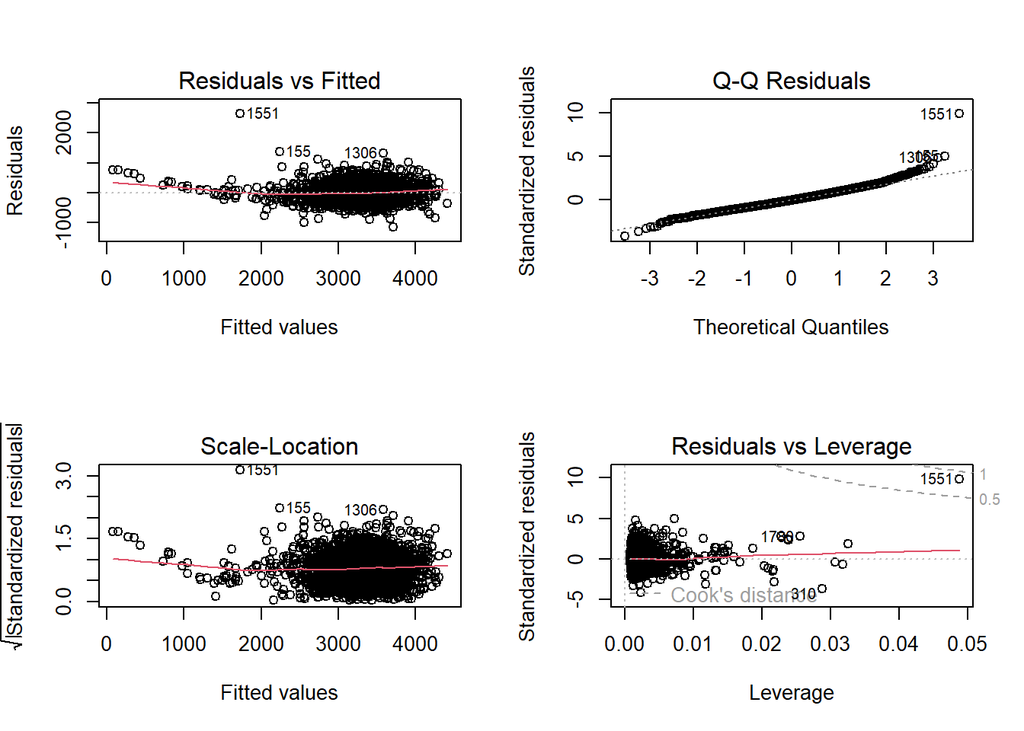

```r
par(mfrow=c(2, 2))

plot(modello_step)
```

# Test sui residui

```r
shapiro.test(residuals(modello_step))
```

```
##
##  Shapiro-Wilk normality test
##
## data:  residuals(modello_step)
## W = 0.97408, p-value < 2.2e-16
```

```r
bptest(modello_step)
```

```
##
##  studentized Breusch-Pagan test
##
## data:  modello_step
## BP = 90.253, df = 5, p-value < 2.2e-16
```

```r
dwtest(modello_step)
```

```
##
##  Durbin-Watson test
##
## data:  modello_step
## DW = 1.9535, p-value = 0.1224
## alternative hypothesis: true autocorrelation is greater than 0
```

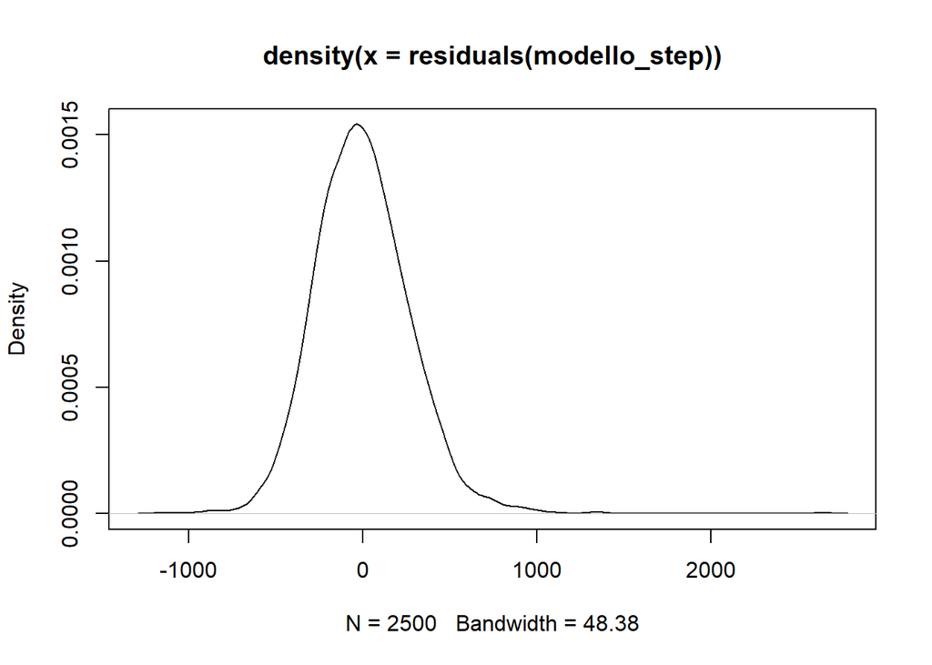

```r
plot(density(residuals(modello_step)))
```

1. Shapiro-Wilk Test (p < 0.05): Rifiutiamo l’ipotesi nulla che i residui siano normalmente distribuiti.
2. Breusch-Pagan Test (p<0.05): Rifiutiamo l’ipotesi nulla di omoscedasticità. Ciò suggerisce che la varianza degli errori non è costante
3. Durbin-Watson Test (p> 0.05): Non possiamo rifiutare l’ipotesi nulla che non ci sia autocorrelazione nei residui. Questo suggerisce che i residui sono indipendenti l’uno dall’altro.

# Verifica dei valori influenti con la statistica Cook’s distance

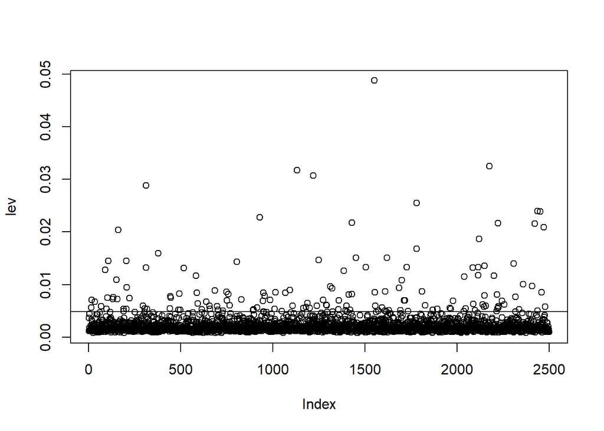

```r
lev = hatvalues(modello_step)
p=sum(lev)
soglia = 2*p/nrow(data)
plot(lev)
abline(h=soglia)
```

```r
outlierTest(modello_step)
```

```
##       rstudent unadjusted p-value Bonferroni p
## 1551 10.051908         2.4906e-23   6.2265e-20
## 155   5.027798         5.3138e-07   1.3285e-03
## 1306  4.827238         1.4681e-06   3.6702e-03
```

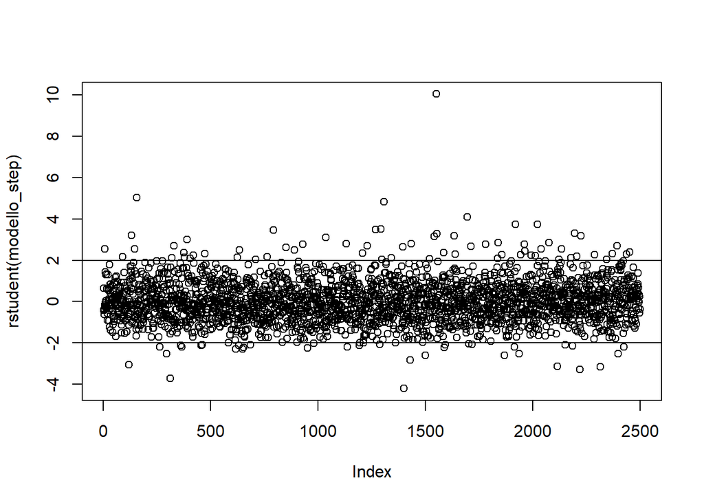

```r
plot(rstudent(modello_step))
abline(h=c(-2,2))
```

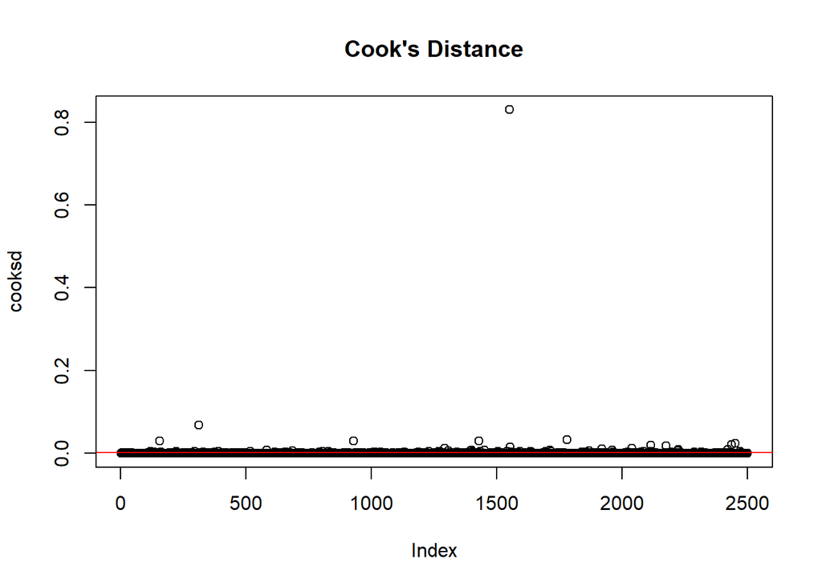

```r
cooksd <- cooks.distance(modello_step)
plot(cooksd, main="Cook's Distance")
abline(h = 4/(nrow(data)-length(coef(modello_step))-1), col="red")
```

Il dato 1551 si conferma come unico valore influente del modello, con una distanza di Cook pari a circa 0.8.

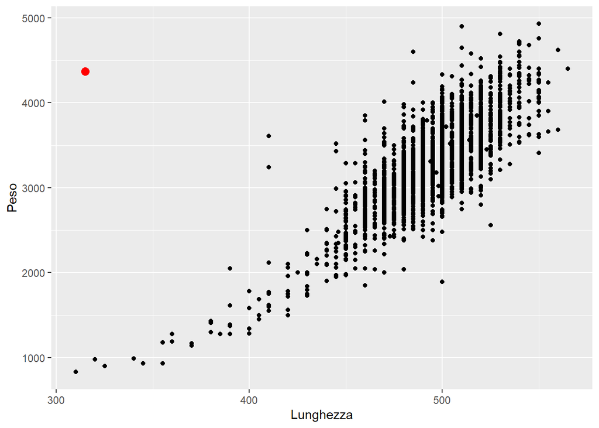

```r
ggplot(data=data)+
  geom_point(aes(x=Lunghezza, y=Peso))+
  geom_point(aes(x=Lunghezza[1551], y=Peso[1551]), color='red', size=3)
```

Il punto sembra essere l’unico a non seguire il trend lineare tra lunghezza e peso. Proviamo ad eliminarlo e ricostruire il modello.

# Modello senza outlier

```r
df_senza_outlier <- data[-1551, ]

modello_step_senza_outlier <- lm(Peso ~ Gestazione + Lunghezza + Cranio + Sesso +
    N.gravidanze, data = df_senza_outlier)

summary(modello_step_senza_outlier)
```

```
##
## Call:
## lm(formula = Peso ~ Gestazione + Lunghezza + Cranio + Sesso +
##     N.gravidanze, data = df_senza_outlier)
##
## Residuals:
##      Min       1Q   Median       3Q      Max
## -1165.74  -179.59   -12.74   162.89  1410.88
##
## Coefficients:
##                Estimate Std. Error t value Pr(>|t|)
## (Intercept)  -6683.4142   133.0802 -50.221  < 2e-16 ***
## Gestazione      29.5891     3.7340   7.924 3.43e-15 ***
## Lunghezza       10.8927     0.3017  36.109  < 2e-16 ***
## Cranio           9.9187     0.4225  23.476  < 2e-16 ***
## SessoM          78.1348    10.9840   7.114 1.47e-12 ***
## N.gravidanze    13.1652     4.2557   3.094    0.002 **
## ---
## Signif. codes:  0 '***' 0.001 '**' 0.01 '*' 0.05 '.' 0.1 ' ' 1
##
## Residual standard error: 269.3 on 2493 degrees of freedom
## Multiple R-squared:  0.7372, Adjusted R-squared:  0.7367
## F-statistic:  1399 on 5 and 2493 DF,  p-value: < 2.2e-16
```

```r
BIC(modello_step_senza_outlier)
```

```
## [1] 35107.74
```

# Test sui residui modello senza outlier

```r
shapiro.test(residuals(modello_step_senza_outlier))
```

```
##
##  Shapiro-Wilk normality test
##
## data:  residuals(modello_step_senza_outlier)
## W = 0.98886, p-value = 4.764e-13
```

```r
bptest(modello_step_senza_outlier)
```

```
##
##  studentized Breusch-Pagan test
##
## data:  modello_step_senza_outlier
## BP = 11.393, df = 5, p-value = 0.04411
```

```r
dwtest(modello_step_senza_outlier)
```

```
##
##  Durbin-Watson test
##
## data:  modello_step_senza_outlier
## DW = 1.954, p-value = 0.1251
## alternative hypothesis: true autocorrelation is greater than 0
```

Il Breusch-Pagan test adesso risulta al limite della significatività, suggerendo che l’ipotesi nulla di omoscedasticità potrebbe essere rispettata. Tuttavia, il test di Shapiro-Wilk mostra ancora un’elevata significatività, pertanto non possiamo accettare l’ipotesi di normalità.

Nel complesso, il modello sembra essere affidabile, con variabili significative e buone proprietà diagnostiche, ad eccezione della normalità dei residui.

# Creiamo un nuovo dataframe con le caratteristiche specifiche

```r
nuovo_neonato <- data.frame(N.gravidanze = 3, Gestazione = 39, Sesso = "F")
```

# Creiamo un nuovo modello senza includere lunghezza e diametro del cranio

```r
modello_ridotto <- lm(Peso ~ N.gravidanze + Gestazione + Sesso,
                      data=df_senza_outlier)

summary(modello_ridotto)
```

```
##
## Call:
## lm(formula = Peso ~ N.gravidanze + Gestazione + Sesso, data = df_senza_outlier)
##
## Residuals:
##      Min       1Q   Median       3Q      Max
## -1493.24  -272.78   -14.31   266.99  1893.87
##
## Coefficients:
##               Estimate Std. Error t value Pr(>|t|)
## (Intercept)  -3142.295    175.092 -17.947  < 2e-16 ***
## N.gravidanze    23.396      6.497   3.601 0.000323 ***
## Gestazione     162.138      4.491  36.105  < 2e-16 ***
## SessoM         166.144     16.701   9.948  < 2e-16 ***
## ---
## Signif. codes:  0 '***' 0.001 '**' 0.01 '*' 0.05 '.' 0.1 ' ' 1
##
## Residual standard error: 413.4 on 2495 degrees of freedom
## Multiple R-squared:  0.3799, Adjusted R-squared:  0.3792
## F-statistic: 509.5 on 3 and 2495 DF,  p-value: < 2.2e-16
```

```r
BIC(modello_ridotto)
```

```
## [1] 37237.33
```

# Predizione con il modello ridotto

```r
predizione <- predict(modello_ridotto, newdata = nuovo_neonato)
predizione
```

```
##        1
## 3251.287
```

#Visualizziamo il modello graficamente

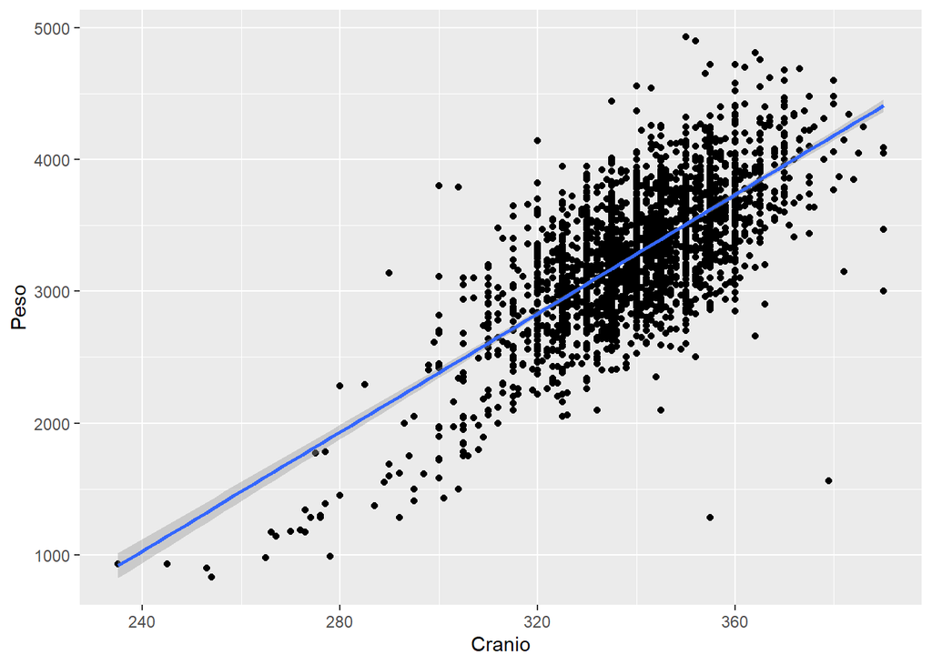

```r
ggplot(data=data)+
  geom_point(aes(x=Cranio, y=Peso)) +
  geom_smooth(aes(x=Cranio, y=Peso), method='lm')
```

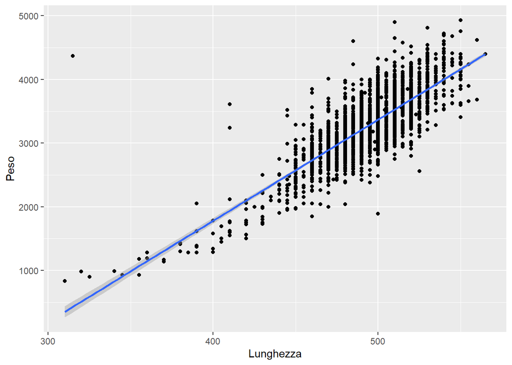

```r
ggplot(data=data)+
  geom_point(aes(x=Lunghezza, y=Peso)) +
  geom_smooth(aes(x=Lunghezza, y=Peso), method='lm')
```

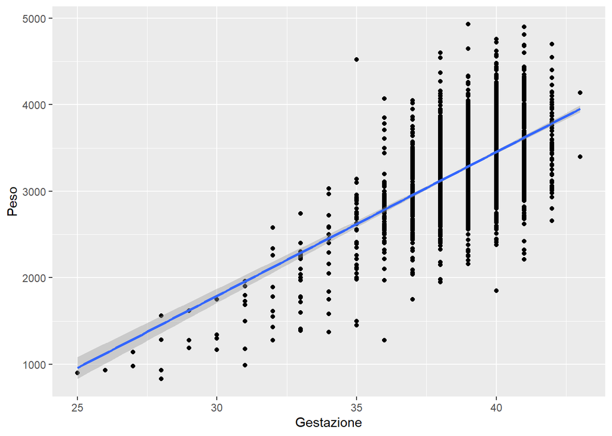

```r
ggplot(data=data)+
  geom_point(aes(x=Gestazione, y=Peso)) +
  geom_smooth(aes(x=Gestazione, y=Peso), method='lm')
```